# Assignment 2: Electricity Market Prices

Hacı Mehmet İnce

8/23/2020

# Introduction

In this assignment, electricity prices data of July, 2020 are analyzed using dplyr and ggplot2. The data used can be accessed on the [website of EPİAŞ](https://rapor.epias.com.tr/rapor/xhtml/ptfSmfListeleme.xhtml).

## Information about Data

The data includes 6 columns and 744 rows, 24 rows for each day in July, 2020. What information each column contains is as follows:

- Date: Date and hour of the recording
- MCP. (renamed as MCP): Market clearing price
- SMP. (renamed as SMP): System marginal price
- Positive.Imbalance.Price..TL.MWh. (renamed as PIP): 0.97xmin(MCP,SMP)
- Negative.Imbalance.Price..TL.MWh. (renamed as NIP): 1.03xmax(MCP,SMP)
- SMP.Direction: Information of comparing energy demand and forecast. When demand is higher than forecast, there is an energy deficit. On the contrary, there is an energy surplus.

# Data Analysis with R

First, the required libraries have been loaded.

```r
library(tidyverse)
library(lubridate)
```

## Data Preparation

Data downloaded in English, loaded from csv file. The “head” function was used to confirm that the data was loaded correctly.

```r
mydata = read.csv("ptf-smf.csv")
head(mydata)
```

```
##             Date   MCP. SMP. Positive.Imbalance.Price..TL.MWh.
## 1 01.07.20 00:00 323.85  211                            204.67
## 2 01.07.20 01:00 326.95  201                            194.97
## 3 01.07.20 02:00 324.31  211                            204.67
## 4 01.07.20 03:00 322.11  211                            204.67
## 5 01.07.20 04:00 320.00  201                            194.97
## 6 01.07.20 05:00 286.21  181                            175.57
##   Negative.Imbalance.Price..TL.MWh.   SMP.Direction
## 1                            333.57 ?Energy Surplus
## 2                            336.76 ?Energy Surplus
## 3                            334.04 ?Energy Surplus
## 4                            331.77 ?Energy Surplus
## 5                            329.60 ?Energy Surplus
## 6                            294.80 ?Energy Surplus
```

Some columns have been renamed to make it easier to work on the data.

```r
names(mydata)[2:5] = c("MCP", "SMP", "PIP", "NIP")

names(mydata)
```

```
## [1] "Date"          "MCP"           "SMP"           "PIP"
## [5] "NIP"           "SMP.Direction"
```

```r
mydata %>% glimpse()
```

```
## Rows: 744
## Columns: 6
## $ Date          <fct> 01.07.20 00:00, 01.07.20 01:00, 01.07.20 02:00, 01…
## $ MCP           <dbl> 323.85, 326.95, 324.31, 322.11, 320.00, 286.21, 21…
## $ SMP           <dbl> 211.00, 201.00, 211.00, 211.00, 201.00, 181.00, 11…
## $ PIP           <dbl> 204.67, 194.97, 204.67, 204.67, 194.97, 175.57, 11…
## $ NIP           <dbl> 333.57, 336.76, 334.04, 331.77, 329.60, 294.80, 21…
## $ SMP.Direction <fct> ?Energy Surplus, ?Energy Surplus, ?Energy Surplus,…
```

```r
mydata = mydata %>%
  mutate(SMP.Direction=case_when(SMP.Direction=="?Energy Surplus" ~ "Surplus", SMP.Direction=="? Energy Deficit"~ "Deficit", SMP.Direction=="? In Balance" ~ "Balance")) %>%
  mutate(Date=as.POSIXct(Date, format="%d.%m.%y %H:%M")) %>%
  mutate(Day=day(Date), Hour=hour(Date), WeekDay=wday(Date))
```

The day of the week has been translated into names to increase readability.

```r
days = c("Sun","Mon","Tue","Wed","Thu","Fri","Sat")
for (i in 1:7){
  mydata$WeekDay = gsub(c(i), days[i], mydata$WeekDay)
}

mydata$WeekDay = factor(mydata$WeekDay, levels= days)
```

A new column was created by taking the difference of SMP and MCP columns. The final version of the data was examined.

```r
mydata$Diff = mydata$SMP - mydata$MCP

mydata %>% glimpse()
```

```
## Rows: 744
## Columns: 10
## $ Date          <dttm> 2020-07-01 00:00:00, 2020-07-01 01:00:00, 2020-07…
## $ MCP           <dbl> 323.85, 326.95, 324.31, 322.11, 320.00, 286.21, 21…
## $ SMP           <dbl> 211.00, 201.00, 211.00, 211.00, 201.00, 181.00, 11…
## $ PIP           <dbl> 204.67, 194.97, 204.67, 204.67, 194.97, 175.57, 11…
## $ NIP           <dbl> 333.57, 336.76, 334.04, 331.77, 329.60, 294.80, 21…
## $ SMP.Direction <chr> "Surplus", "Surplus", "Surplus", "Surplus", "Surpl…
## $ Day           <int> 1, 1, 1, 1, 1, 1, 1, 1, 1, 1, 1, 1, 1, 1, 1, 1, 1,…
## $ Hour          <int> 0, 1, 2, 3, 4, 5, 6, 7, 8, 9, 10, 11, 12, 13, 14, …
## $ WeekDay       <fct> Wed, Wed, Wed, Wed, Wed, Wed, Wed, Wed, Wed, Wed, …
## $ Diff          <dbl> -112.85, -125.95, -113.31, -111.11, -119.00, -105.…
```

## Data Visualization

The chart below was created to see the general distribution of SMP and MCP.

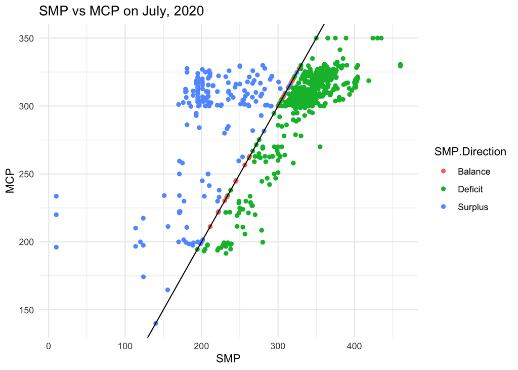

```r
ggplot(mydata, aes(x=SMP, y=MCP, color= SMP.Direction)) +
  geom_point() +
  theme_minimal() +
  ggtitle("SMP vs MCP on July, 2020") +
  labs(x = "SMP", y = "MCP") +
  geom_abline(slope=1, intercept=0)
```

In the graph above, it is clearly seen that market clearing price is higher than system marginal price when there is energy surplus.

The average of SMP and MCP according to the days of the week was found and recorded as AvgofWeekDays.

```r
AvgofWeekDays =
  mydata %>%
  group_by(WeekDay) %>%
  summarise(AvgSMP = mean(SMP), AvgMCP = mean(MCP), AvgDiff = mean(Diff))
```

The same was done according to the time of day, recorded as AvgofHours.

```r
AvgofHours =
  mydata %>%
  group_by(Hour) %>%
  summarise(AvgMCP = mean(MCP), AvgSMP = mean(SMP), AvgDiff = mean(Diff))
```

The information has been reorganized in order to make it graphics.

```r
pivotAvgofWeekDays =
  AvgofWeekDays %>%
  ungroup() %>%
  pivot_longer(cols=c(AvgMCP, AvgSMP), names_to="SMPorMCP", values_to="Price")
```

```r
pivotAvgofHours =
  AvgofHours %>%
  ungroup() %>%
  pivot_longer(cols=c(AvgMCP, AvgSMP), names_to="SMPorMCP", values_to="Price")
```

[figure not shown]

```r
ggplot(pivotAvgofWeekDays,aes(x=WeekDay,y=Price,fill=SMPorMCP)) +
  geom_bar(stat="Identity",position = "dodge") +
  scale_fill_manual(values = c("darkblue", "darkgreen"), name = "", labels = c("SMP", "MCP")) +
  theme_minimal() +
  labs(x="Week Day", y="Price", title="Avg Prices by Week Day")
```

As can be seen from the graph above, prices are lower than on other days as demand is lower on Sundays, possibly due to holidays.

[figure not shown]

```r
ggplot(pivotAvgofHours,aes(x=Hour,y=Price,fill=SMPorMCP)) +
  geom_bar(stat="Identity",position = "dodge") +
  scale_fill_manual(values=c("darkblue", "darkgreen"), name = "", labels = c("SMP", "MCP")) +
  theme_minimal() +
  labs(x="Hour", y="Price", title="Avg Prices by Hour")
```

As can be seen from the graph above, as the early morning hours are approaching, prices are lower than other hours due to the fact that electricity consumption decreases the most. Also, there is a slight decrease in the hours that coincide with the lunch break.

If the graphics are created according to the difference (SMP - MCP), the following results are obtained.

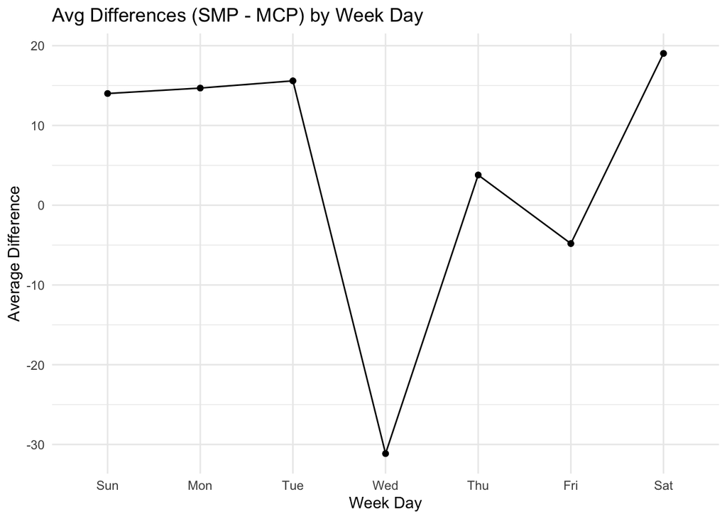

```r
ggplot(data=pivotAvgofWeekDays, aes(x=WeekDay, y=AvgDiff, group=1)) +
  geom_line() +
  geom_point() +
  theme_minimal() +
  labs(x="Week Day", y="Average Difference", title="Avg Differences (SMP - MCP) by Week Day")
```

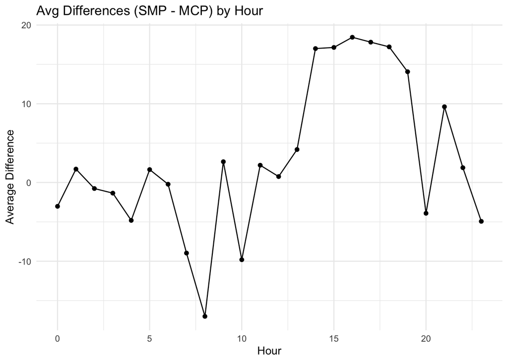

```r
ggplot(data=pivotAvgofHours, aes(x=Hour, y=AvgDiff)) +
  geom_line() +
  geom_point() +
  theme_minimal() +
  labs(x="Hour", y="Average Difference", title="Avg Differences (SMP - MCP) by Hour")
```